# Prudential Live Insurance Assessment

Ruben Maso

15 Diciembre 2015

Este documento es un análisis exploratorio de los datos del concurso de Kaggle Prudential Live Insurance Assessment. El conjunto de datos puede encontrarse en [Kaggle](https://www.kaggle.com/c/prudential-life-insurance-assessment).

El conjunto de datos se compone de las siguientes variables:

| Variable | Description |
| --- | --- |
| Id | Un identificador único asociado con la solicitud |
| Product_Info_1-7 | Un conjunto de variables normalizadas relativas al producto solicitado |
| Ins_Age | Edad normalizada del solicitante |
| Ht | Altura normalizada del solicitante |
| Wt | Peso normalizado del solicitante |
| BMI | IMC Normalizado del solicitante |
| Employment_Info_1-6 | Un conjunto de variables normalizadas relativas a la historia de empleo del solicitante |
| InsuredInfo_1-6 | Un conjunto de variables normalizadas sobre información del solicitante |
| Insurance_History_1-9 | Un conjunto de variables normalizadas relacionados con la historia del seguro del solicitante |
| Family_Hist_1-5 | Un conjunto de variables normalizadas relativas a la historia familiar del solicitante |
| Medical_History_1-41 | Un conjunto de variables normalizadas con respecto a la historia clínica del solicitante |
| Medical_Keyword_1-48 | Un conjunto de variables ficticias relativas a la presencia/ausencia de una palabra clave médica que se asocia con la solicitud |
| Response | Esta es la variable objetivo, una variable ordinal relativo a la decisión final asociado con la solicitud |

| Tipologia de las variables | Listado |
| --- | --- |
| Categoricas | Product_Info_1, Product_Info_2, Product_Info_3, Product_Info_5, Product_Info_6, Product_Info_7, Employment_Info_2, Employment_Info_3, Employment_Info_5, InsuredInfo_1, InsuredInfo_2, InsuredInfo_3, In… |
| Continuas | Product_Info_4, Ins_Age, Ht, Wt, BMI, Employment_Info_1, Employment_Info_4, Employment_Info_6, Insurance_History_5, Family_Hist_2, Family_Hist_3, Family_Hist_4, Family_Hist_5 |
| Discretas | Medical_History_1, Medical_History_15, Medical_History_24, Medical_History_32 |
| Dummy | Medical_Keyword_1-48 |

### Lectura de los datos

Procedemos a la lectura de los datos cargando la estructura indicada en la sección anterior:

```r
library(data.table)
library(ggplot2)
library(gridExtra)
library(caret)
colClasses=c("integer","factor","factor","factur","numeric","factor","factor","factor",
             "numeric","numeric","numeric","numeric","numeric","factor","factor","numeric","factor","numeric",
             "factor","factor","factor","factor","factor","factor","factor",
             "factor","factor","factor","factor","numeric","factor","factor","factor",
             "factor","numeric","numeric","numeric","numeric",
             "integer","factor","factor","factor","factor","factor","factor","factor","factor","factor",
             "factor","factor","factor","factor",
             "integer","factor","factor","factor","factor","factor","factor","factor","factor",
             "integer","factor","factor","factor","factor","factor","factor","factor",
             "integer","factor","factor","factor","factor","factor","factor","factor","factor","factor",
             "integer","integer","integer","integer","integer","integer","integer","integer","integer","integer",
             "integer","integer","integer","integer","integer","integer","integer","integer","integer","integer",
             "integer","integer","integer","integer","integer","integer","integer","integer","integer","integer",
             "integer","integer","integer","integer","integer","integer","integer","integer","integer","integer",
             "integer","integer","integer","integer","integer","integer","integer","integer","factor")
train <- fread("../data/train.csv", colClasses=colClasses, stringsAsFactors=TRUE)
```

```
##
Read 0.0% of 59381 rows
Read 59381 rows and 128 (of 128) columns from 0.019 GB file in 00:00:03
```

```r
test <- fread("../data/test.csv", colClasses = colClasses[-length(colClasses)], stringsAsFactors=TRUE)

cat.var.names <- c(paste("Product_Info_", c(1:3,5:7), sep=""), paste("Employment_Info_", c(2,3,5), sep=""),
                   paste("InsuredInfo_", 1:7, sep=""), paste("Insurance_History_", c(1:4,7:9), sep=""),
                   "Family_Hist_1", paste("Medical_History_", c(2:14, 16:23, 25:31, 33:41), sep=""))
cont.var.names <- c("Product_Info_4", "Ins_Age", "Ht", "Wt", "BMI", "Employment_Info_1", "Employment_Info_4",
                    "Employment_Info_6", "Insurance_History_5", "Family_Hist_2", "Family_Hist_3", "Family_Hist_4",
                    "Family_Hist_5")
disc.var.names <- c("Medical_History_1", "Medical_History_15", "Medical_History_24", "Medical_History_32",
                    paste("Medical_Keyword_", 1:48, sep=""))
```

### Exploración de datos

Primero vamos a ver la estructura de los datos:

```r
str(train)
```

```
## Classes 'data.table' and 'data.frame':   59381 obs. of  128 variables:
##  $ Id                 : int  2 5 6 7 8 10 11 14 15 16 ...
##  $ Product_Info_1     : Factor w/ 2 levels "1","2": 1 1 1 1 1 1 1 1 1 1 ...
##  $ Product_Info_2     : Factor w/ 19 levels "A1","A2","A3",..: 17 1 19 18 16 16 8 16 17 19 ...
##  $ Product_Info_3     : Factor w/ 34 levels "1","10","11",..: 2 17 17 2 17 17 2 17 17 13 ...
##  $ Product_Info_4     : num  0.0769 0.0769 0.0769 0.4872 0.2308 ...
##  $ Product_Info_5     : Factor w/ 2 levels "2","3": 1 1 1 1 1 2 1 1 1 1 ...
##  $ Product_Info_6     : Factor w/ 2 levels "1","3": 1 2 2 2 2 1 2 2 2 2 ...
##  $ Product_Info_7     : Factor w/ 3 levels "1","2","3": 1 1 1 1 1 1 1 1 1 1 ...
##  $ Ins_Age            : num  0.6418 0.0597 0.0299 0.1642 0.4179 ...
##  $ Ht                 : num  0.582 0.6 0.745 0.673 0.655 ...
##  $ Wt                 : num  0.149 0.132 0.289 0.205 0.234 ...
##  $ BMI                : num  0.323 0.272 0.429 0.352 0.424 ...
##  $ Employment_Info_1  : num  0.028 0 0.03 0.042 0.027 0.325 0.11 0.12 0.165 0.025 ...
##  $ Employment_Info_2  : Factor w/ 36 levels "1","10","11",..: 4 1 36 36 36 7 1 4 36 1 ...
```

[output cut: 87 more lines]

```r
str(test)
```

```
## Classes 'data.table' and 'data.frame':   19765 obs. of  127 variables:
##  $ Id                 : int  1 3 4 9 12 13 21 28 30 36 ...
##  $ Product_Info_1     : Factor w/ 2 levels "1","2": 1 1 1 1 1 1 1 1 1 1 ...
##  $ Product_Info_2     : Factor w/ 19 levels "A1","A2","A3",..: 17 2 17 1 1 17 3 18 17 3 ...
##  $ Product_Info_3     : Factor w/ 26 levels "10","11","14",..: 12 12 12 12 12 12 12 12 12 12 ...
##  $ Product_Info_4     : num  0.4872 0.0769 0.1447 0.1517 0.0769 ...
##  $ Product_Info_5     : Factor w/ 2 levels "2","3": 1 1 1 1 1 1 1 1 1 1 ...
##  $ Product_Info_6     : Factor w/ 2 levels "1","3": 2 2 2 1 2 2 2 2 2 2 ...
##  $ Product_Info_7     : Factor w/ 2 levels "1","3": 1 1 1 1 1 1 1 1 1 1 ...
##  $ Ins_Age            : num  0.612 0.627 0.582 0.522 0.299 ...
##  $ Ht                 : num  0.782 0.727 0.709 0.655 0.673 ...
##  $ Wt                 : num  0.339 0.312 0.32 0.268 0.247 ...
##  $ BMI                : num  0.472 0.485 0.519 0.487 0.429 ...
##  $ Employment_Info_1  : num  0.15 0 0.143 0.21 0.085 0.075 0.14 0.025 0.035 0.06 ...
##  $ Employment_Info_2  : Factor w/ 28 levels "1","10","11",..: 18 1 28 28 28 28 28 28 28 28 ...
```

[output cut: 87 more lines]

```r
summary(train)
```

```
##        Id        Product_Info_1 Product_Info_2  Product_Info_3
##  Min.   :    2   1:57816        D3     :14321   26     :50892
##  1st Qu.:19780   2: 1565        D4     :10812   10     : 6008
##  Median :39487                  A8     : 6835   29     : 1334
##  Mean   :39507                  D1     : 6554   31     :  411
##  3rd Qu.:59211                  D2     : 6286   15     :  251
##  Max.   :79146                  E1     : 2647   37     :  139
##                                 (Other):11926   (Other):  346
##  Product_Info_4    Product_Info_5 Product_Info_6 Product_Info_7
##  Min.   :0.00000   2:58968        1: 9691        1:58086
##  1st Qu.:0.07692   3:  413        3:49690        2:    2
##  Median :0.23077                                 3: 1293
##  Mean   :0.32895
##  3rd Qu.:0.48718
##  Max.   :1.00000
##
##     Ins_Age             Ht               Wt              BMI
##  Min.   :0.0000   Min.   :0.0000   Min.   :0.0000   Min.   :0.0000
##  1st Qu.:0.2388   1st Qu.:0.6545   1st Qu.:0.2259   1st Qu.:0.3855
##  Median :0.4030   Median :0.7091   Median :0.2887   Median :0.4513
##  Mean   :0.4056   Mean   :0.7073   Mean   :0.2926   Mean   :0.4695
##  3rd Qu.:0.5672   3rd Qu.:0.7636   3rd Qu.:0.3452   3rd Qu.:0.5329
##  Max.   :1.0000   Max.   :1.0000   Max.   :1.0000   Max.   :1.0000
##
##  Employment_Info_1 Employment_Info_2 Employment_Info_3 Employment_Info_4
##  Min.   :0.00000   9      :34573     1:50447           Min.   :0.000
##  1st Qu.:0.03500   1      : 8934     3: 8934           1st Qu.:0.000
##  Median :0.06000   12     : 7714                       Median :0.000
##  Mean   :0.07758   14     : 4819                       Mean   :0.006
##  3rd Qu.:0.10000   3      : 1724                       3rd Qu.:0.000
##  Max.   :1.00000   15     :  480                       Max.   :1.000
##  NA's   :19        (Other): 1137                       NA's   :6779
##  Employment_Info_5 Employment_Info_6 InsuredInfo_1 InsuredInfo_2
##  2:50892           Min.   :0.000     1:47223       2:58940
##  3: 8489           1st Qu.:0.060     2:11886       3:  441
##                    Median :0.250     3:  272
##                    Mean   :0.361
##                    3rd Qu.:0.550
##                    Max.   :1.000
##                    NA's   :10854
```

[output cut: 249 more lines]

```
##  Min.   :0.00000    Min.   :0.000000   Min.   :0.00000
##  1st Qu.:0.00000    1st Qu.:0.000000   1st Qu.:0.00000
##  Median :0.00000    Median :0.000000   Median :0.00000
##  Mean   :0.01071    Mean   :0.007528   Mean   :0.01369
##  3rd Qu.:0.00000    3rd Qu.:0.000000   3rd Qu.:0.00000
##  Max.   :1.00000    Max.   :1.000000   Max.   :1.00000
##
##  Medical_Keyword_46 Medical_Keyword_47 Medical_Keyword_48    Response
##  Min.   :0.000000   Min.   :0.00000    Min.   :0.0000     8      :19489
##  1st Qu.:0.000000   1st Qu.:0.00000    1st Qu.:0.0000     6      :11233
##  Median :0.000000   Median :0.00000    Median :0.0000     7      : 8027
##  Mean   :0.008488   Mean   :0.01991    Mean   :0.0545     2      : 6552
##  3rd Qu.:0.000000   3rd Qu.:0.00000    3rd Qu.:0.0000     1      : 6207
##  Max.   :1.000000   Max.   :1.00000    Max.   :1.0000     5      : 5432
##                                                           (Other): 2441
```

El conjunto de test tiene 19765 filas, mientras que el conjunto de entrenamiento tiene 59381 filas. La clasificación pública se basa en el 39% de los datos y la clasificación privada se basa en el restante 61%.

### Tratamiento del los nulos

El 4.3979635 % de valores perdidos (missing data). Para cada una de las variables:

```r
train.md <-apply(train, 2, function(x) { sum(is.na(x)) })

train.md[train.md!=0]
```

```
##   Employment_Info_1   Employment_Info_4   Employment_Info_6
##                  19                6779               10854
## Insurance_History_5       Family_Hist_2       Family_Hist_3
##               25396               28656               34241
##       Family_Hist_4       Family_Hist_5   Medical_History_1
##               19184               41811                8889
##  Medical_History_15  Medical_History_24  Medical_History_32
##               44596               55580               58274
```

Vamos a comprobar el tipo y contenido de esas variables:

```r
summary(train[,train.md!=0,with = FALSE])
```

```
##  Employment_Info_1 Employment_Info_4 Employment_Info_6 Insurance_History_5
##  Min.   :0.00000   Min.   :0.000     Min.   :0.000     Min.   :0.000
##  1st Qu.:0.03500   1st Qu.:0.000     1st Qu.:0.060     1st Qu.:0.000
##  Median :0.06000   Median :0.000     Median :0.250     Median :0.001
##  Mean   :0.07758   Mean   :0.006     Mean   :0.361     Mean   :0.002
##  3rd Qu.:0.10000   3rd Qu.:0.000     3rd Qu.:0.550     3rd Qu.:0.002
##  Max.   :1.00000   Max.   :1.000     Max.   :1.000     Max.   :1.000
##  NA's   :19        NA's   :6779      NA's   :10854     NA's   :25396
##  Family_Hist_2   Family_Hist_3   Family_Hist_4   Family_Hist_5
##  Min.   :0.000   Min.   :0.00    Min.   :0.000   Min.   :0.00
##  1st Qu.:0.362   1st Qu.:0.40    1st Qu.:0.324   1st Qu.:0.40
##  Median :0.464   Median :0.52    Median :0.423   Median :0.51
##  Mean   :0.475   Mean   :0.50    Mean   :0.445   Mean   :0.48
##  3rd Qu.:0.580   3rd Qu.:0.60    3rd Qu.:0.563   3rd Qu.:0.58
##  Max.   :1.000   Max.   :1.00    Max.   :0.944   Max.   :1.00
##  NA's   :28656   NA's   :34241   NA's   :19184   NA's   :41811
##  Medical_History_1 Medical_History_15 Medical_History_24
##  Min.   :  0.000   Min.   :  0.0      Min.   :  0.00
##  1st Qu.:  2.000   1st Qu.: 17.0      1st Qu.:  1.00
##  Median :  4.000   Median :117.0      Median :  8.00
##  Mean   :  7.962   Mean   :123.8      Mean   : 50.64
##  3rd Qu.:  9.000   3rd Qu.:240.0      3rd Qu.: 64.00
##  Max.   :240.000   Max.   :240.0      Max.   :240.00
##  NA's   :8889      NA's   :44596      NA's   :55580
##  Medical_History_32
##  Min.   :  0.00
##  1st Qu.:  0.00
##  Median :  0.00
##  Mean   : 11.97
##  3rd Qu.:  2.00
##  Max.   :240.00
##  NA's   :58274
```

Gráfico de los datos faltantes (solo para las variables con datos faltantes) donde la variable con más datos faltantes está arriba y la que tienes menos bajo.

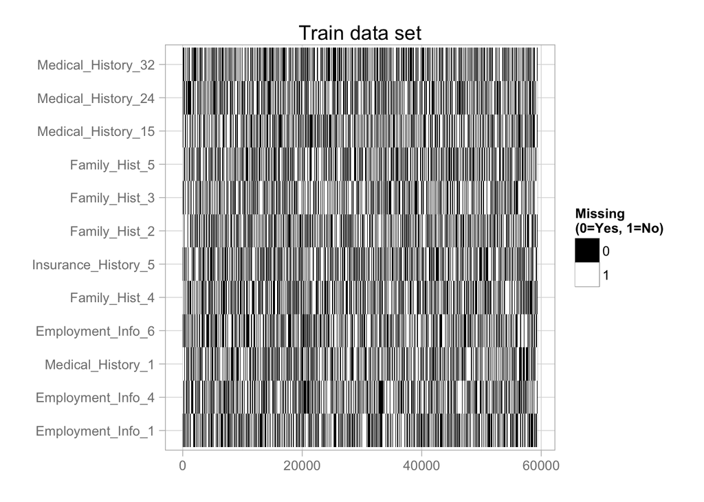

```r
plotMissingnessStr <- function(data.in, title=NULL) {
  r <- as.data.frame(ifelse(is.na(data.in), 0, 1))
  r <- r[,order(colMeans(is.na(data.in)))]
  dat.tmp <- expand.grid(list(x=1:nrow(r), y=colnames(r)))
  dat.tmp$r <- as.vector(t(r))

  ggplot(dat.tmp) + geom_tile(aes(x=x, y=y, fill=factor(r))) + scale_fill_manual(values=c("black", "white"), name="Missing\n(0=Yes, 1=No)") + theme_light() + ylab("") + xlab("") + ggtitle(title)
}

plotMissingnessStr(data.in=as.data.frame(train)[,apply(train, 2, function(x) { sum(is.na(x)) > 0 })], title="Train data set")
```

### Columnas constantes

¿Existe alguna columna constanteo con baja variabilidad? Mostramos las variables con un freqCut = 99/1

```r
nzv <- nearZeroVar(train, freqCut = 99/1, saveMetrics = TRUE)
```

Existen 0 variables constantes. Las variables con baja variabilidad son:

```r
summary(train[, rownames(nzv)[nzv$nzv], with=FALSE])
```

```
##  Product_Info_5 Employment_Info_4 InsuredInfo_2 Medical_History_5
##  2:58968        Min.   :0.000     2:58940       1:58946
##  3:  413        1st Qu.:0.000     3:  441       2:  433
##                 Median :0.000                   3:    2
##                 Mean   :0.006
##                 3rd Qu.:0.000
##                 Max.   :1.000
##                 NA's   :6779
##  Medical_History_10 Medical_History_11 Medical_History_27
##         :58824      1:   88            1:  584
##  240    :  270      2:  190            2:    7
##  0      :   75      3:59103            3:58790
##  1      :   22
##  2      :   13
##  5      :   10
##  (Other):  167
##  Medical_History_31 Medical_History_35 Medical_History_38
##  1:  437            1:59319            1:59093
##  2:    1            2:    2            2:  288
##  3:58943            3:   60
##
##
##
##
##  Medical_Keyword_2  Medical_Keyword_5  Medical_Keyword_9
##  Min.   :0.000000   Min.   :0.000000   Min.   :0.000000
##  1st Qu.:0.000000   1st Qu.:0.000000   1st Qu.:0.000000
##  Median :0.000000   Median :0.000000   Median :0.000000
##  Mean   :0.008942   Mean   :0.008622   Mean   :0.006652
##  3rd Qu.:0.000000   3rd Qu.:0.000000   3rd Qu.:0.000000
##  Max.   :1.000000   Max.   :1.000000   Max.   :1.000000
##
##  Medical_Keyword_13 Medical_Keyword_14 Medical_Keyword_17
##  Min.   :0.000000   Min.   :0.000000   Min.   :0.000000
##  1st Qu.:0.000000   1st Qu.:0.000000   1st Qu.:0.000000
##  Median :0.000000   Median :0.000000   Median :0.000000
##  Mean   :0.005961   Mean   :0.007848   Mean   :0.009161
##  3rd Qu.:0.000000   3rd Qu.:0.000000   3rd Qu.:0.000000
##  Max.   :1.000000   Max.   :1.000000   Max.   :1.000000
##
```

[output cut: 9 more lines]

```
##  Min.   :0.000000   Min.   :0.000000   Min.   :0.000000
##  1st Qu.:0.000000   1st Qu.:0.000000   1st Qu.:0.000000
##  Median :0.000000   Median :0.000000   Median :0.000000
##  Mean   :0.006938   Mean   :0.006837   Mean   :0.007528
##  3rd Qu.:0.000000   3rd Qu.:0.000000   3rd Qu.:0.000000
##  Max.   :1.000000   Max.   :1.000000   Max.   :1.000000
##
##  Medical_Keyword_46
##  Min.   :0.000000
##  1st Qu.:0.000000
##  Median :0.000000
##  Mean   :0.008488
##  3rd Qu.:0.000000
##  Max.   :1.000000
##
```

### Gráficos

Histogramas de las varaibles categoricas

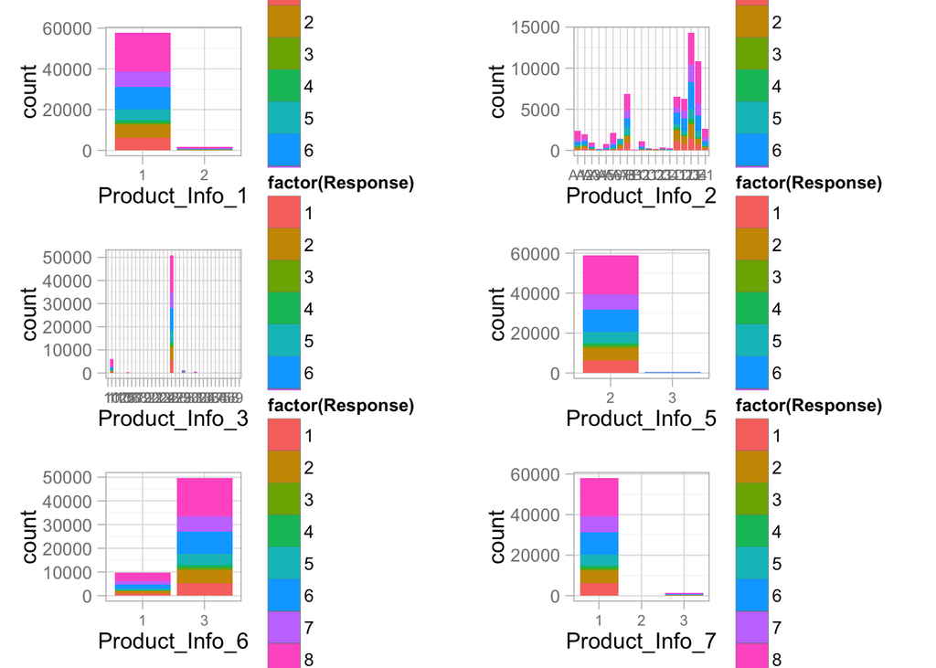

```r
plotHist <- function(data.in, i) {
  data <- data.frame(x=data.in[,i], Response=data.in$Response)
  p <- ggplot(data=data, aes(x=factor(x), fill=factor(Response))) + geom_histogram() + xlab(colnames(data.in)[i]) + theme_light() +
    theme(axis.text.x=element_text(size=8))
  return (p)
}

doPlots <- function(data.in, fun, ii, ncol=3) {
  pp <- list()
  for (i in ii) {
    p <- fun(data.in=data.in, i=i)
    pp <- c(pp, list(p))
  }
  do.call("grid.arrange", c(pp, ncol=ncol))
}
train.cat <- data.frame(train[ , cat.var.names, with=FALSE], Response=train$Response)

doPlots(data.in=train.cat, fun=plotHist, ii=1:6, ncol=2)
```

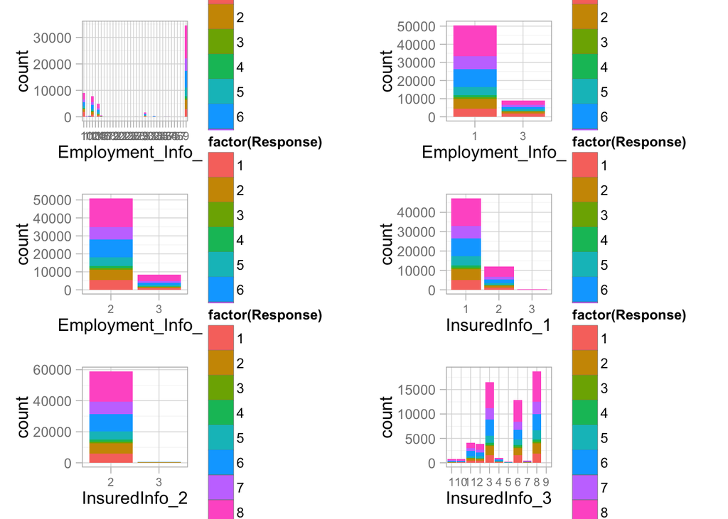

```r
doPlots(data.in=train.cat, fun=plotHist, ii=7:12, ncol=2)
```

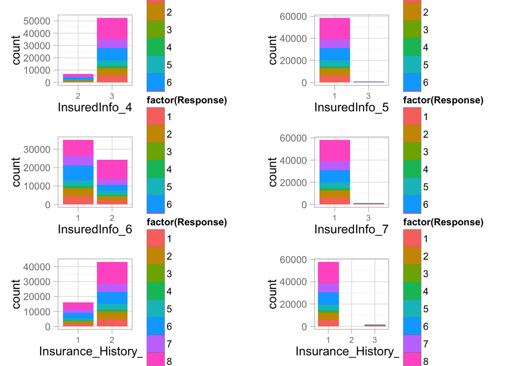

```r
doPlots(data.in=train.cat, fun=plotHist, ii=13:18, ncol=2)
```

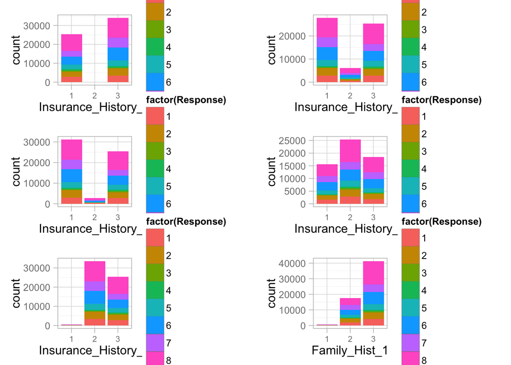

```r
doPlots(data.in=train.cat, fun=plotHist, ii=19:24, ncol=2)
```

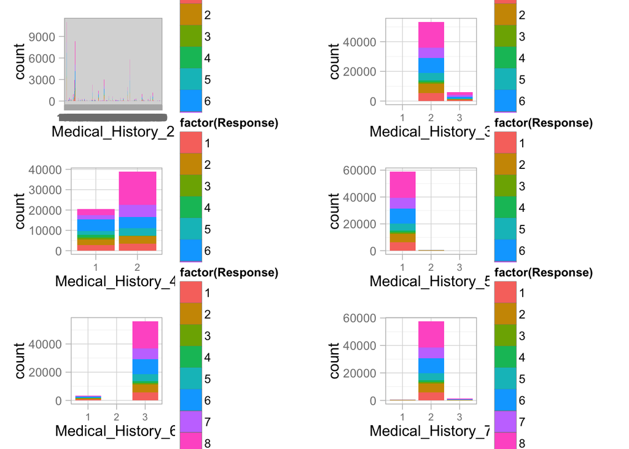

```r
doPlots(data.in=train.cat, fun=plotHist, ii=25:30, ncol=2)
```

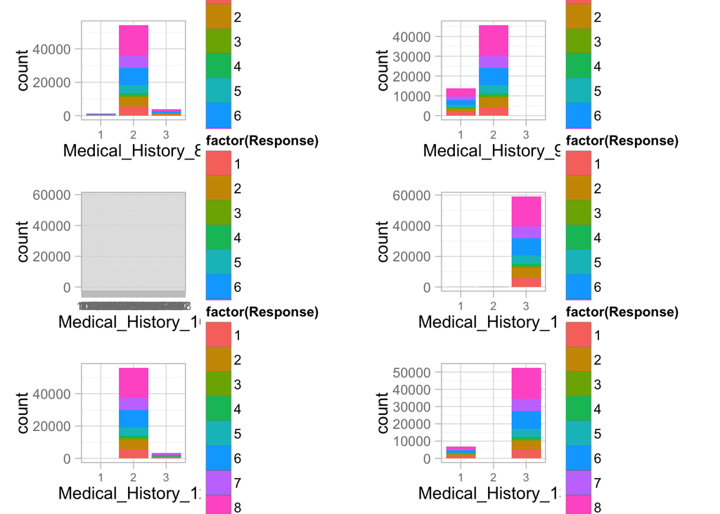

```r
doPlots(data.in=train.cat, fun=plotHist, ii=31:36, ncol=2)
```

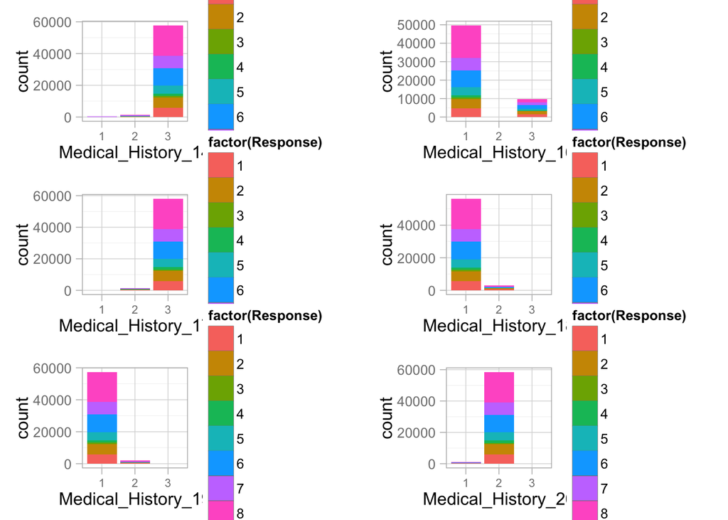

```r
doPlots(data.in=train.cat, fun=plotHist, ii=37:42, ncol=2)
```

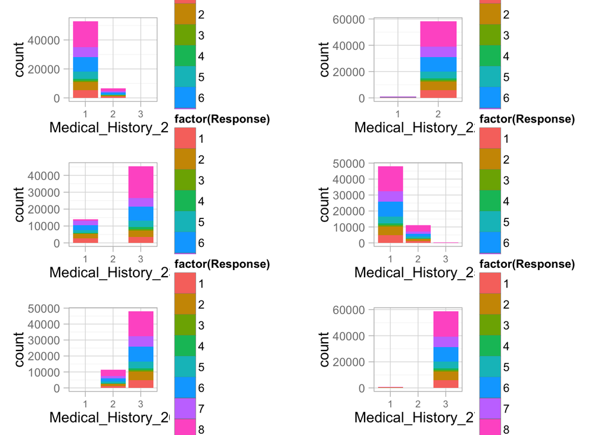

```r
doPlots(data.in=train.cat, fun=plotHist, ii=43:48, ncol=2)
```

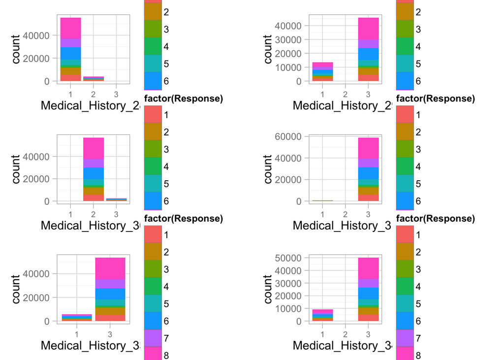

```r
doPlots(data.in=train.cat, fun=plotHist, ii=49:54, ncol=2)
```

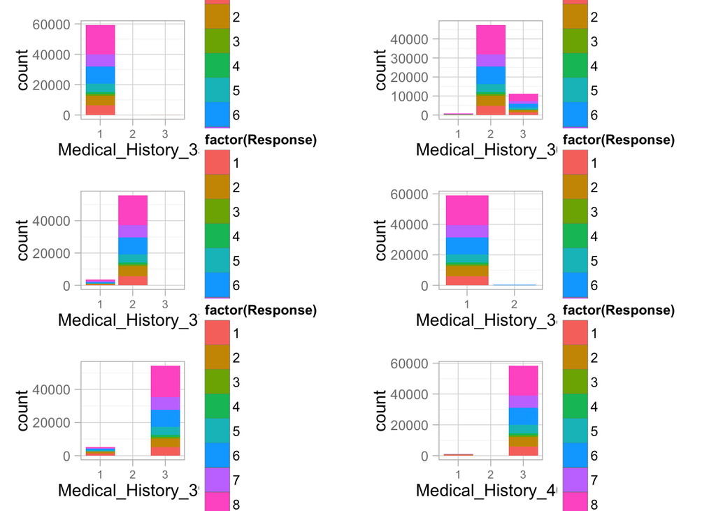

```r
doPlots(data.in=train.cat, fun=plotHist, ii=55:60, ncol=2)
```

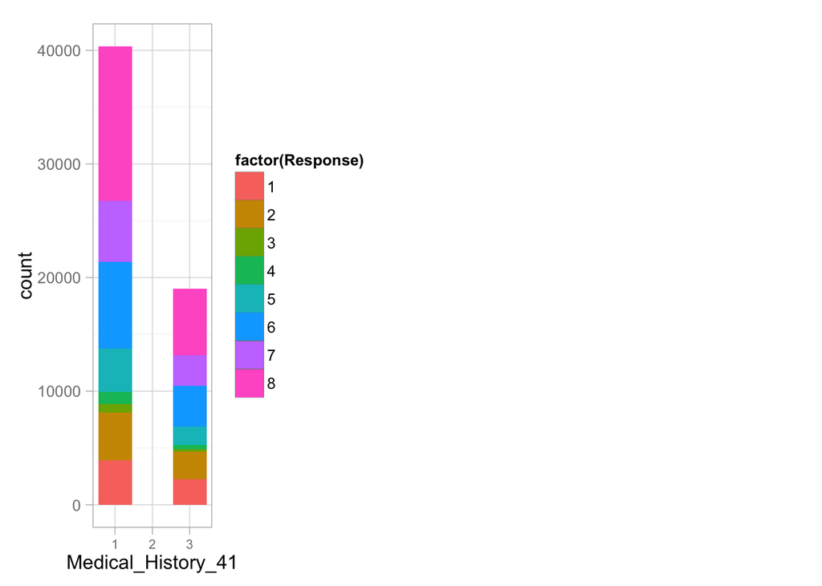

```r
doPlots(data.in=train.cat, fun=plotHist, ii=61, ncol=2)
```

Funciones de densidad para las variables continuas

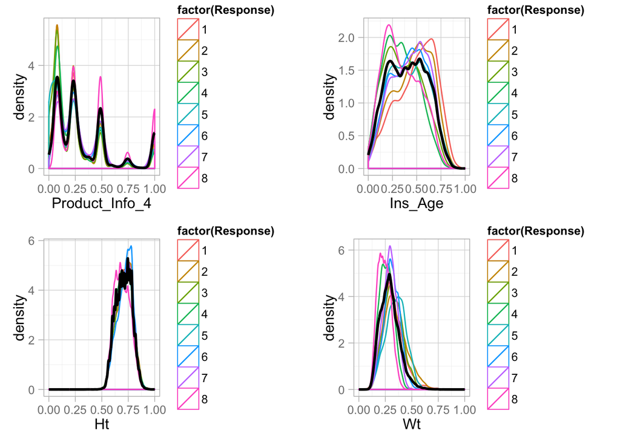

```r
train.cont <- data.frame(train[ , cont.var.names, with=FALSE], Response=train$Response)
plotDensity <- function(data.in, i) {
  data <- data.frame(x=data.in[,i], Response=data.in$Response)
  p <- ggplot(data) + geom_density(aes(x=x, colour=factor(Response))) +
    geom_line(aes(x=x), stat="density", size=1, alpha=1.0) +
    xlab(colnames(data.in)[i]) + theme_light()
  return (p)
}

doPlots(data.in=train.cont, fun=plotDensity, ii=1:4, ncol=2)
```

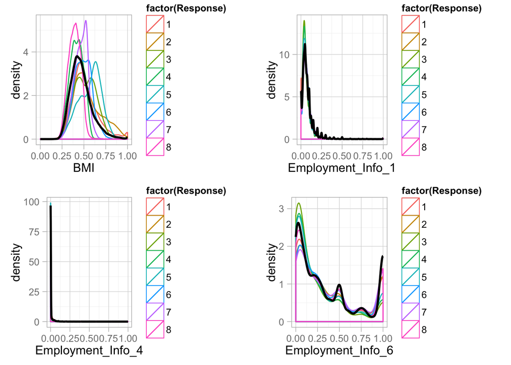

```r
doPlots(data.in=train.cont, fun=plotDensity, ii=5:8, ncol=2)
```

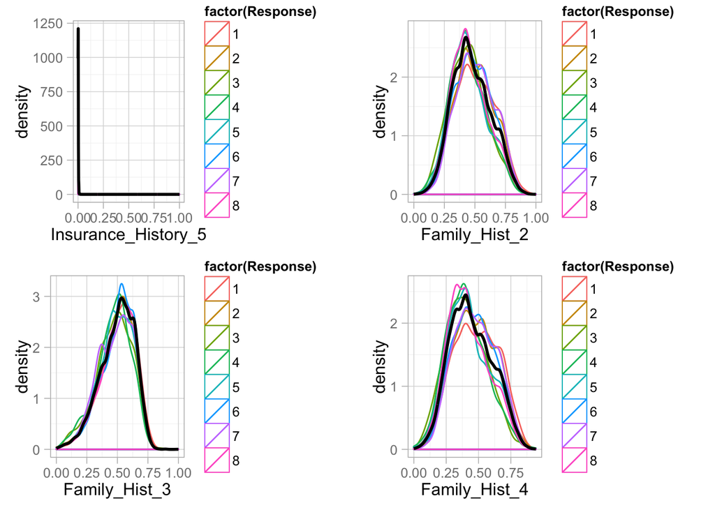

```r
doPlots(data.in=train.cont, fun=plotDensity, ii=9:12, ncol=2)
```

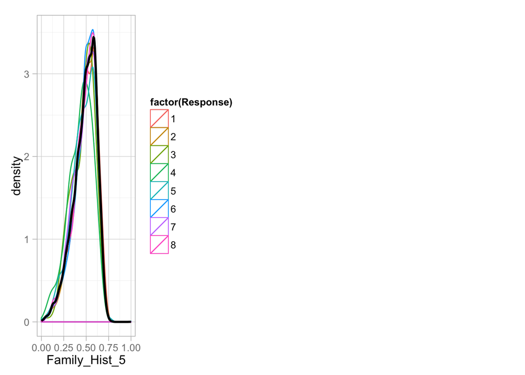

```r
doPlots(data.in=train.cont, fun=plotDensity, ii=13, ncol=2)
```

Boxplots para las variables continuas dependiente de Response

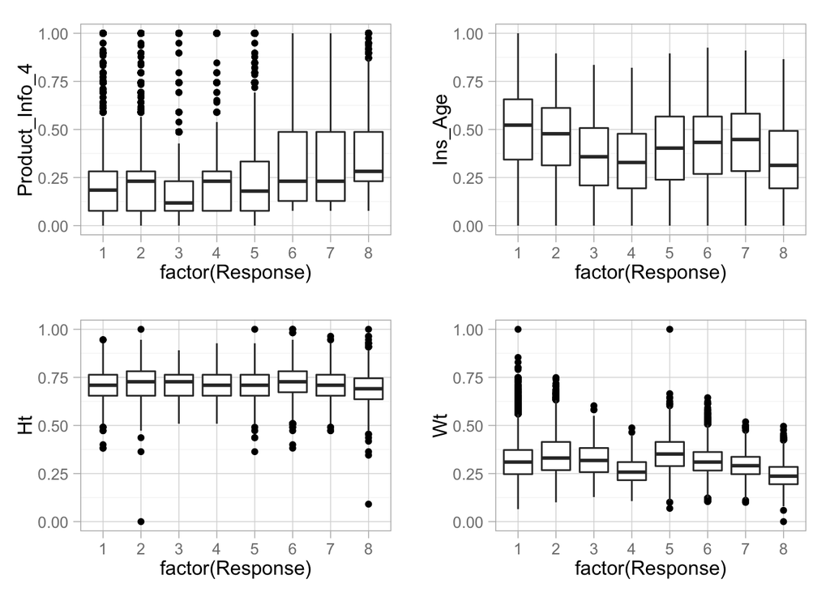

```r
plotBox <- function(data.in, i) {
  data <- data.frame(y=data.in[,i], Response=data.in$Response)
  p <- ggplot(data, aes(x=factor(Response), y=y)) + geom_boxplot() + ylab(colnames(data.in)[i]) + theme_light()
  return (p)
}

doPlots(data.in=train.cont, fun=plotBox, ii=1:4, ncol=2)
```

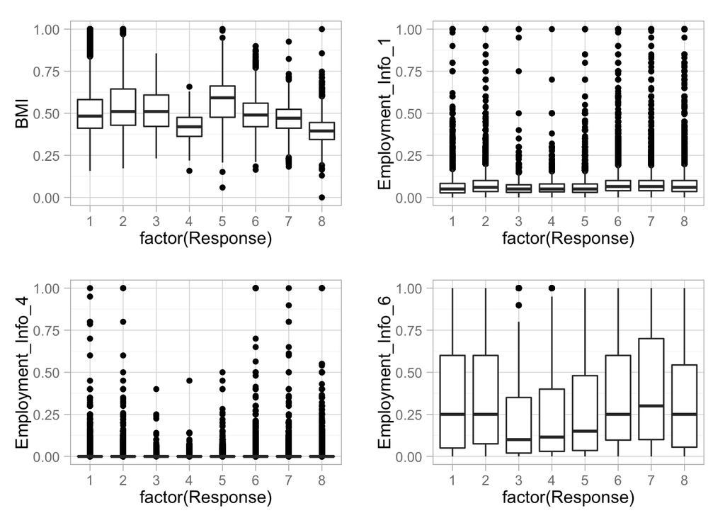

```r
doPlots(data.in=train.cont, fun=plotBox, ii=5:8, ncol=2)
```

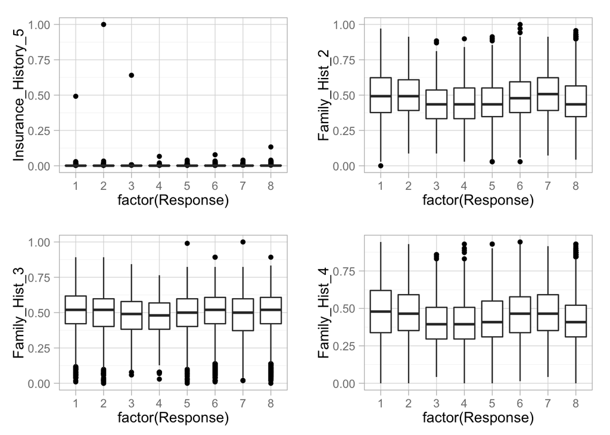

```r
doPlots(data.in=train.cont, fun=plotBox, ii=9:12, ncol=2)
```

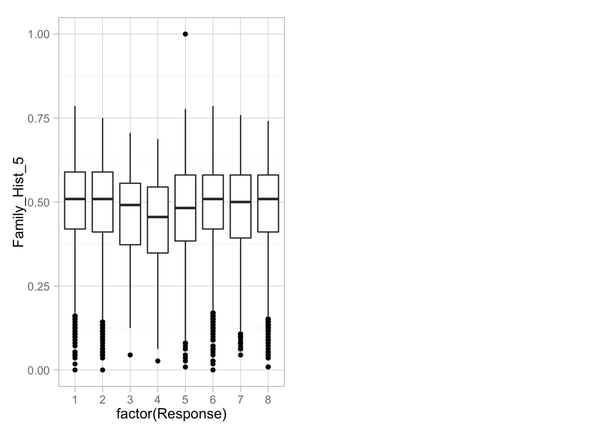

```r
doPlots(data.in=train.cont, fun=plotBox, ii=13, ncol=2)
```

Vamos a ver la variable respuesta

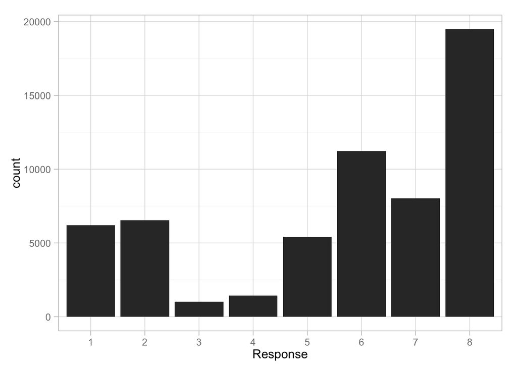

```r
ggplot(train) + geom_histogram(aes(factor(Response))) + xlab("Response") + theme_light()
```